# SingleGEO: Query and Integrative Analysis of High-throughput Single Cell Sequencing Data from GEO

Author: Yuanqing Yan bioinformatics.yuanqing@gmail.com

03 January, 2022

## Description

Single cell next generation sequencing technologies have advanced the research to examine the genomic alterations from individual cells. Single cell Assay for Transposase Accessible Chromatin with high-throughput sequencing (scATAC-seq) enables the research of chromatin-accessibility signatures across the entire genome. Single cell RNAseq (scRNAseq) studies the single-cell transcriptomics to better understand the differential cell compositions as wells as the molecular profile changes. Currently a huge amount of single cell genetic data have been deposited in GEO and the number is keeping on exponentially increasing. These single cell high-throughput sequencing data come from different tissues, health status, disease stage and drug treatments. Various machine learning algorithms, such as canonical correlation analysis and reciprocal principal component analysis, have been adapted in single cell data analysis. The implementation of such algorithms correct the potential batch effects and make the data integration between different datasets feasible. SingleGEO is developed to efficiently query, download high-throughput single cell sequencing data from GEO and perform and integrative analysis. The program will initially download GEO meta database into local drive and implement a fast and light-weight searching engine to query the database. By feeding the program with the keywords relevant to the user’s research interests, the query results with specific meta information will be returned for further investigation. Once the targeted GSE IDs have been selected, the single cell sequencing data deposited in GEO supplement can be downloaded into local derive. In addition, singleGEO provides pipelines to easily generate Seurat objects from raw/normalized data and perform an integrative analysis with multiple datasets using Seurat framework. Novel findings can be obtained through the integrative analysis from different datasets.

## Installation

Installing singleGEO from GitHub

```r
library(devtools)
devtools::install_github("yuanqingyan/singleGEO")
```

## Download GEO meta database

SingleGEO uses sql to query the database. To perform the database searching, GEO meta database should be first downloaded and save in the local drive. The name of the geo meta dataset usually is GEOmetadb.sqlite. If the meta database has been already downloaded and not the in the current working folder, specify the path of this file. In this vignett, a demo file is used for demonstration purpose.

```r
library(singleGEO)
##Download the GEO meta database. Remove "Demo=TRUE" or set "Demo=FALSE" when you start your own project.
MyDataBase<-GetGeoMetaDatabase(Sqlfile=NULL,Demo=TRUE)
```

```
#> [1] "Using demo GEO meta database"
```

## Query the database

To query the database, the organisms and a list of keywords should be provided. For the organism, one or multiple organisms can be provided. By providing a list of keywords, the query will return the results with the keywords described in GEO meta data. One or multiple keywords can be provided. For each keyword, to overcome the ambiguity, multiple options can be provided. For example, “pulmonary” could be an alternative word used for lung study. The program will searching the database by recognizing the different options for each key point. The following code is to search the potential available GEO datasets, assuming we are interested in scRNAseq data in lung study from both human and mouse.

```r
# Will study mouse and human data
MyOrganism<-c("Mus musculus","Homo sapiens")
# Will study lung. Some study may use "pulmonary" instead of "lung", so two options are specified
search_kw1<-c("lung","pulmonary")
KeyList<-list(kw1=search_kw1)
MySearch<-Get_Keyword_Meta(GeoDataBase=MyDataBase,
                           Organism=MyOrganism,
                           InputSearchList=KeyList)
```

```
#> [1] "Database searching"
```

```r
colnames(MySearch)
```

```
#> [1] "title"              "gse"                "summary"
#> [4] "type"               "overall_design"     "supplementary_file"
```

```r
unique(MySearch$gse)
```

```
#>  [1] "GSE42564"  "GSE52583"  "GSE69405"  "GSE73121"  "GSE86618"  "GSE94555"
#>  [7] "GSE98048"  "GSE96106"  "GSE97168"  "GSE106960" "GSE109444" "GSE103918"
#> [13] "GSE103919" "GSE104154" "GSE99254"  "GSE117618" "GSE102580" "GSE103354"
#> [19] "GSE117450" "GSE117617" "GSE118704" "GSE118706" "GSE116031" "GSE113320"
#> [25] "GSE121611" "GSE122960" "GSE126205" "GSE126906" "GSE126908" "GSE100412"
#> [31] "GSE115730" "GSE128033" "GSE123838" "GSE128169" "GSE131800" "GSE124258"
#> [37] "GSE135893" "GSE121600" "GSE127803" "GSE136580" "GSE129914" "GSE139229"
#> [43] "GSE139231" "GSE140431" "GSE133992" "GSE108378" "GSE142285" "GSE142286"
#> [49] "GSE124323" "GSE124324" "GSE137026" "GSE138585" "GSE123902" "GSE137912"
#> [55] "GSE129937" "GSE130077" "GSE132771" "GSE135167" "GSE128822" "GSE131907"
#> [61] "GSE134174" "GSE137353" "GSE132533" "GSE132534" "GSE132910" "GSE132914"
#> [67] "GSE143705" "GSE143706" "GSE154869" "GSE154870" "GSE154965" "GSE154966"
#> [73] "GSE154977" "GSE154978" "GSE154989" "GSE123405" "GSE149655" "GSE140032"
#> [79] "GSE149813" "GSE137950" "GSE146981" "GSE141141" "GSE142246" "GSE140203"
#> [85] "GSE158127" "GSE160760" "GSE160876" "GSE161648" "GSE149878" "GSE159354"
#> [91] "GSE160664" "GSE151974" "GSE161934" "GSE162045"
```

```r
head(MySearch[,c("title","gse")])
```

```
#>                                                                                                                                                               title
#> 1                                                                              Gene expression analysis of lung fibroblasts in bleomycin-induced pulmonary fibrosis
#> 2                                                                              Gene expression analysis of lung fibroblasts in bleomycin-induced pulmonary fibrosis
#> 3 High throughput quantitative whole transcriptome analysis of distal mouse lung epithelial cells from various developmental stages (E14.5, E16.5, E18.5 and adult)
#> 4 High throughput quantitative whole transcriptome analysis of distal mouse lung epithelial cells from various developmental stages (E14.5, E16.5, E18.5 and adult)
#> 5 High throughput quantitative whole transcriptome analysis of distal mouse lung epithelial cells from various developmental stages (E14.5, E16.5, E18.5 and adult)
#> 6 High throughput quantitative whole transcriptome analysis of distal mouse lung epithelial cells from various developmental stages (E14.5, E16.5, E18.5 and adult)
#>        gse
#> 1 GSE42564
#> 2 GSE42564
#> 3 GSE52583
#> 4 GSE52583
#> 5 GSE52583
#> 6 GSE52583
```

```r
MySearch[MySearch$gse=="GSE158127","summary"][1]
```

```
#> [1] "Lung transplantation can potentially be a life-saving treatment for patients with non-resolving COVID-19-associated respiratory failure. Concerns limiting transplant include recurrence of SARS-CoV-2 infection in the allograft, technical challenges imposed by viral-mediated injury to the nati…
```

SingleGEO can query scRNAseq and scATACseq datasets simultaneously. The following code searches the datasets which are from either scRANseq or scATACseq and relevant to human adenocarcinoma disease.

```r
Organism_hs<-c("Homo sapiens")
Data_platform<-c("scRNAseq","scATACseq")
search_kw_ade<-c("adenocarcinoma")
KeyList_ade<-list(kw_ad=search_kw_ade)
MySearch_ade<-Get_Keyword_Meta(GeoDataBase=MyDataBase,
                               Organism=Organism_hs,
                               InputSearchList=KeyList_ade,
                               Platform=Data_platform)
```

```
#> [1] "Database searching"
```

```r
unique(MySearch_ade$gse)
```

```
#>  [1] "GSE69405"  "GSE97168"  "GSE99254"  "GSE117618" "GSE117450" "GSE117617"
#>  [7] "GSE118704" "GSE118706" "GSE126906" "GSE126908" "GSE108378" "GSE142285"
#> [13] "GSE142286" "GSE123902" "GSE137912" "GSE128822" "GSE131907" "GSE154869"
#> [19] "GSE154870" "GSE149655" "GSE141141" "GSE162045"
```

Title of one scATACseq study

```r
MySearch_ade[MySearch_ade$gse=="GSE142285","title"][1]
```

```
#> [1] "Designing a single cell ATAC-Seq (scATAC-Seq) dataset to validate long read RNA-Seq isoforms and benchmark scATAC-Seq analysis methods"
```

For some studies, a combination of both scRNAseq and scATACseq are performed. SingleGEO can identify such datasets by intersecting the query results. The following code is to search for mouse brain study with both scRNAseq and scATACseq.

```r
MyOrganism_ms<-c("Mus musculus")
search_brain<-c("brain")
KeyList_brain<-list(kw_brain=search_brain)

MySearch_brain_scRNA<-Get_Keyword_Meta(GeoDataBase=MyDataBase,
                                       Organism=MyOrganism_ms,
                                       InputSearchList=KeyList_brain,
                                       Platform="scRNAseq")
```

```
#> [1] "Database searching"
```

```r
MySearch_brain_scATAC<-Get_Keyword_Meta(GeoDataBase=MyDataBase,
                                        Organism=MyOrganism_ms,
                                        InputSearchList=KeyList_brain,
                                        Platform="scATACseq")
```

```
#> [1] "Database searching"
```

```r
(Both_RNA_ATAC<-intersect(unique(MySearch_brain_scRNA$gse),
                          unique(MySearch_brain_scATAC$gse)))
```

```
#> [1] "GSE126074" "GSE132534"
```

```r
MySearch_brain_scRNA[MySearch_brain_scRNA$gse==Both_RNA_ATAC[1],"overall_design"][1]
```

```
#> [1] "Single nuclei RNA-seq and ATAC-seq co-assay for BJ, H1, K562 and GM12878 cell mixture, and wild type postnatal day 0 mouse brain cerebral cortex."
```

To obtain more specific studies, multiple keywords should be provided. The following codes can be used to query scRNAseq datasets in mouse, and such datasets should focus on lung fibrosis and new or novel subtype of cell population should be reported.

```r
search_kw2<-c("fibrosis")
search_kw3<-c("new","novel")
search_kw4<-c("subtype","subpopulation")
KeyList_new<-list(kw1=search_kw1,
                  kw2=search_kw2,
                  kw3=search_kw3,
                  kw4=search_kw4)
MySearch_new<-Get_Keyword_Meta(GeoDataBase=MyDataBase,
                               Organism=MyOrganism_ms,
                               InputSearchList=KeyList_new)
```

```
#> [1] "Database searching"
```

```r
unique(MySearch_new$gse)
```

```
#> [1] "GSE104154"
```

Title of this gse dataset

```r
MySearch_new[1,"title"]
```

```
#> [1] "Single Cell Analysis of Pulmonary Fibrotic Mesenchymal Cells Indicates a New Subtype"
```

Summary of this study

```r
MySearch_new$summary[1]
```

```
#> [1] "Stromal  taxonomy consists of multiple cell subtypes that play a critical role in tissue repair or regeneration, fibrosis, inflammation, angiogenesis and tumor formation. However, their identities are not fully understood, as these conventional classified populations have historically been d…
```

Design of this study

```
MySearch_new$overall_design[1]
```

```
#> [1] "Stratification of lung mesenchymal subtypes in normal and fibrotic stages."
```

We can also obtain the gsm information of each study.

```r
gsm_info<-Get_GSMFromGSE(GeoDataBase=MyDataBase,
                         GSE.ID=MySearch_new$gse[1])
colnames(gsm_info)
```

```
#> [1] "title"                  "gsm"                    "gse"
#> [4] "source_name_ch1"        "characteristics_ch1"    "treatment_protocol_ch1"
#> [7] "treatment_protocol_ch2"
```

Gsm title and id

```r
gsm_info[,c("title","gsm")]
```

```
#>         title        gsm
#> 1  d0_SMA+Tm+ GSM2790885
#> 2  d0_SMA-Tm+ GSM2790886
#> 3  d0_SMA-Tm- GSM2790887
#> 4 d21_SMA+TM+ GSM2790888
#> 5 d21_SMA-TM+ GSM2790889
#> 6 d21_SMA-TM- GSM2790890
```

SingleGEO can be used to query different datasets for integrative analysis. Suppose we are also doing a fas-signaling project in lung fibrosis (fas-signaling has been reported to be up-regulated in lung epithelial cells from patients with idiopathic pulmonary fibrosis) and wondering whether there are some scRNAseq datasets available in mouse. If we could find some, we would like to integrate them with the previous searching result (novel cell type in mouse lung fibrosis) and evaluate whether fas-signaling pathway affect the novel cell type (this example will be described in data integration part).

```r
search_kw5<-c("fas-signaling","fas signaling","fas pathway","fas-pathway")
KeyList_fas<-list(kw1=search_kw1,
                  kw2=search_kw2,
                  kw5=search_kw5)
MySearch_fas<-Get_Keyword_Meta(GeoDataBase=MyDataBase,
                               Organism=MyOrganism_ms,
                               InputSearchList=KeyList_fas)
```

```
#> [1] "Database searching"
```

```r
unique(MySearch_fas$gse)
```

```
#> [1] "GSE161648"
```

Title of this study

```r
MySearch_fas[1,"title"]
```

```
#> [1] "Loss of Fas-signaling in pro-fibrotic fibroblasts impairs homeostatic fibrosis resolution and promotes persistent pulmonary fibrosis"
```

Design of this study

```
MySearch_fas$overall_design[1]
```

```
#> [1] "Bulk RNA-seq,: Naïve(4 reps) + 3wk_Fas-- (4 reps) + 3wk_Fas++ (4 reps) + 6wk_Fas-- (4 reps) + 6wk_Fas++ (4 reps)  scRNA-seq: paired Naive, 3wk_Fas--, 3wk_Fas++, 6wk_Fas--, 6wk_Fas++"
```

Summary of this study

```r
MySearch_fas$summary[1]
```

```
#> [1] "Idiopathic pulmonary fibrosis (IPF) is a progressive, irreversible fibrotic disease of the distal lung alveoli that culminates in respiratory failure and reduced lifespan. Unlike normal lung repair in response to injury, IPF is associated with the accumulation and persistence of fibroblasts …
```

Available supplement data

```r
MySearch_fas$supplementary_file[1]
```

```
#> [1] "ftp://ftp.ncbi.nlm.nih.gov/geo/series/GSE161nnn/GSE161648/suppl/GSE161648_RAW.tar;\tftp://ftp.ncbi.nlm.nih.gov/geo/series/GSE161nnn/GSE161648/suppl/GSE161648_norm_count.txt.gz;\tftp://ftp.ncbi.nlm.nih.gov/geo/series/GSE161nnn/GSE161648/suppl/GSE161648_raw_count.txt.gz"
```

## Use singleGEO to download the single cell high-throughput sequencing data

By providing the GSE IDs, the single cell high-throughput sequencing data deposited in the supplement will be downloaded for further analysis.

```r
myGeoID<-c("GSE140032")
##Set DecompressFile=TRUE if you want to download and decompress the data in the same time
DownloadFileInfo<-Get_Geo_Data(DownGSEID=myGeoID,DecompressFile=FALSE)
DownloadFileInfo
```

```
#>       GSE140032
#>  [1,] "GSE140032_RAW.tar"
#>  [2,] "GSM4151704_GLI1+_cell_PBS_barcodes.tsv"
#>  [3,] "GSM4151704_GLI1+_cell_PBS_barcodes.tsv.gz"
#>  [4,] "GSM4151704_GLI1+_cell_PBS_genes.tsv"
#>  [5,] "GSM4151704_GLI1+_cell_PBS_genes.tsv.gz"
#>  [6,] "GSM4151704_GLI1+_cell_PBS_matrix.mtx"
#>  [7,] "GSM4151704_GLI1+_cell_PBS_matrix.mtx.gz"
#>  [8,] "GSM4151705_GLI1+_cell_Bleo_barcodes.tsv"
#>  [9,] "GSM4151705_GLI1+_cell_Bleo_barcodes.tsv.gz"
#> [10,] "GSM4151705_GLI1+_cell_Bleo_genes.tsv"
#> [11,] "GSM4151705_GLI1+_cell_Bleo_genes.tsv.gz"
#> [12,] "GSM4151705_GLI1+_cell_Bleo_matrix.mtx"
#> [13,] "GSM4151705_GLI1+_cell_Bleo_matrix.mtx.gz"
```

```r
ExtractFile(ExtractID=myGeoID,DecompressType=c("tar","gz"))
list.files("GSE140032")
```

```
#>  [1] "GSE140032_RAW.tar"
#>  [2] "GSM4151704_GLI1+_cell_PBS_barcodes.tsv"
#>  [3] "GSM4151704_GLI1+_cell_PBS_barcodes.tsv.gz"
#>  [4] "GSM4151704_GLI1+_cell_PBS_genes.tsv"
#>  [5] "GSM4151704_GLI1+_cell_PBS_genes.tsv.gz"
#>  [6] "GSM4151704_GLI1+_cell_PBS_matrix.mtx"
#>  [7] "GSM4151704_GLI1+_cell_PBS_matrix.mtx.gz"
#>  [8] "GSM4151705_GLI1+_cell_Bleo_barcodes.tsv"
#>  [9] "GSM4151705_GLI1+_cell_Bleo_barcodes.tsv.gz"
#> [10] "GSM4151705_GLI1+_cell_Bleo_genes.tsv"
#> [11] "GSM4151705_GLI1+_cell_Bleo_genes.tsv.gz"
#> [12] "GSM4151705_GLI1+_cell_Bleo_matrix.mtx"
#> [13] "GSM4151705_GLI1+_cell_Bleo_matrix.mtx.gz"
```

Different groups have different preference in storing and uploading the data to GEO. If a Seurat object is provided by the submitter, the data can be read into Seurat directly for further analysis. For hdf5 format file, R packages of “rhdf5” and/or “SeuratDisk” could be helpful for data access. For the study with only raw count data and/or normalized data provided, SingleGEO provides “MakeSeuObj_FromRawRNAData” and “MakeSeuObj_FromNormalizedRNAData” to quickly make the Seurat object.

## Make Seurat object from raw sequencing data

SingleGEO can make the Seurat object from the raw data it downloaded by running “MakeSeuObj_FromRawRNAData”. Before running “MakeSeuObj_FromRawRNAData”, a list of raw data should be constructed. Each element of the list is for each individual sample and the name of the element corresponds to the name of the sample. “MakeSeuObj_FromRawRNAData” performs the scRNAseq data quality control by filtering out cells with potential doublets, dead cells or empty droplets. If all cells want to be kept or the cells have been filtered, set a big number of maxFeature,maxCount,maxMT and small number of minFeature,minCount. SingleGEO also conducts dimension reduction and makes the Seurat object for the downstream analysis.

```r
###The following code generate an example dataset from GSE134174 (The same data has been built and can be loaded by data(testData_GSE134174)). Note that only 4 samples with 800 cells were selected for illustration purpose.
# Get_Geo_Data(DownGSEID="GSE134174",DecompressFile="TRUE",DecompressType="All")
# selPatient<-c("T101","T85","T153","T164")
# raw_GSE134174<-read.delim("./GSE134174/GSE134174_Processed_invivo_raw.txt",header=T,sep="\t")
# meta_GSE134174<-read.delim("./GSE134174/GSE134174_Processed_invivo_metadata.txt",header=T,sep="\t")
# meta_sel0<-meta_GSE134174[meta_GSE134174$Donor %in% selPatient,]
# raw_sel0<-raw_GSE134174[,colnames(raw_GSE134174) %in% meta_sel0$Cell]
# set.seed(12345);sampleIndex<-sample(1:nrow(meta_sel0),size=800)
# meta_sel<-meta_sel0[sampleIndex,];raw_sel<-raw_sel0[,paste(meta_sel$Cell)]
# raw_sel<-raw_sel[rowSums(raw_sel)>0,]
# testData_GSE134174<-list(TwoRawData=raw_sel,TwoMetaData=meta_sel)

data(testData_GSE134174)
test_meta<-testData_GSE134174$TwoMetaData
test_data<-testData_GSE134174$TwoRawData
list_GSE134174<-Splitdata_MakeDataList(InputData=test_data,Group=test_meta$Donor)
##The following code setting a big number of maxFeature,maxCount,maxMT and small number ##of minFeature,minCount will keep all the cells
seu_GSE134174<-MakeSeuObj_FromRawRNAData(RawList=list_GSE134174,
                                      GSE.ID="GSE134174",
                                      MinFeature=1,
                                      MaxFeature=750000,
                                      MinCount=1,
                                      MaxCount=4000000,
                                      MaxMT=100)
names(seu_GSE134174)
```

```
#> [1] "T164" "T101" "T85"  "T153"
```

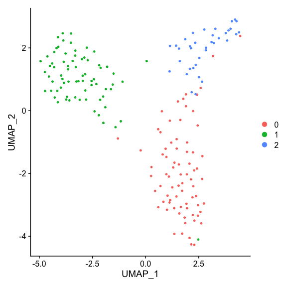

```r
Seurat::DimPlot(seu_GSE134174[[1]],repel = TRUE)
```

```r
####Use sctransform normalization and make Seurat object
seu_GSE134174_sct<-MakeSeuObj_FromRawRNAData(RawList=list_GSE134174,
                                          GSE.ID="GSE134174",
                                          MinFeature=1,
                                          MaxFeature=750000,
                                          MinCount=1,
                                          MaxCount=4000000,
                                          MaxMT=100,
                                          Norm.method = "sct")
names(seu_GSE134174_sct)
```

```
#> [1] "T164" "T101" "T85"  "T153"
```

## Make Seurat object from normalized data

Normalized scRNAseq data could be available and may be the only dataset provided by the data submitter. SingleGEO can use normalized dataset to make the Seurat object. For the normalized data, assume the cells are in good quality and no further filtering is necessary.

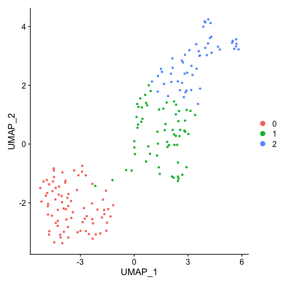

```r
#####to make Seurat object from normalized by LogNormalized method
#Norm_GSE134174<-lapply(seu_GSE134174,function(x) {Seurat::GetAssayData(x,slot = "data")})
data(Norm_GSE134174)
seu_Norm_GSE134174<-MakeSeuObj_FromNormalizedRNAData(NormList=Norm_GSE134174,GSE.ID="GSE134174")
Seurat::DimPlot(seu_Norm_GSE134174[[1]],repel = TRUE)
```

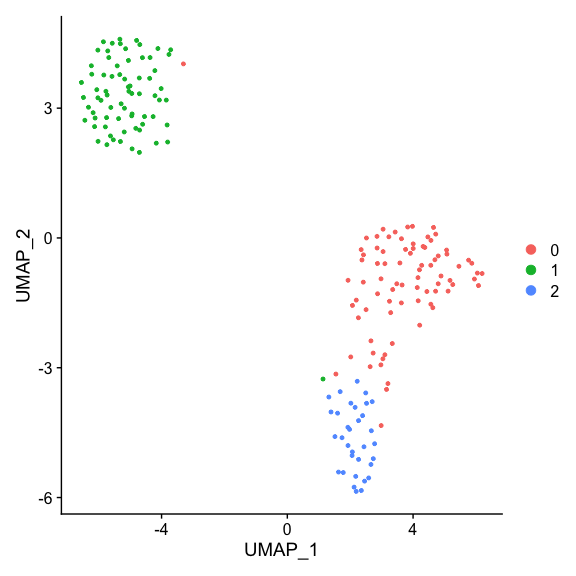

```r
#####to make Seurat object from normalized by sctransform method
list_Norm.sct_GSE134174<-lapply(seu_GSE134174_sct,function(x) Seurat::GetAssayData(x,slot="data"))
seu_Norm.sct_GSE134174<-MakeSeuObj_FromNormalizedRNAData(NormList=list_Norm.sct_GSE134174,Frow.which.Norm="sct",GSE.ID="GSE134174")
Seurat::DimPlot(seu_Norm.sct_GSE134174[[1]],repel = TRUE)
```

## Data integration

Multiple datasets can be integrated for the analysis. These datasets could be obtained from one single GSE ID or multiple GSE IDs. The following examples illustrate the integrative analysis of example datasets from one single GSE ID (GSE134174).

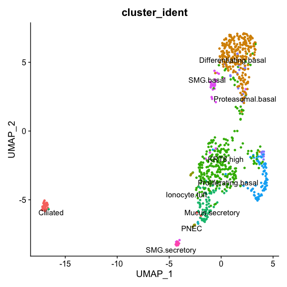

```r
Int_GSE134174<-SeuObj_integration(Object.list=seu_GSE134174)
###Add additional meta data
row.names(test_meta)<-test_meta$Cell
test_meta<-test_meta[row.names(Int_GSE134174@meta.data),]
Int_GSE134174<-Seurat::AddMetaData(object=Int_GSE134174,metadata =as.data.frame(test_meta))
Seurat::DimPlot(Int_GSE134174,group.by="cluster_ident",label=TRUE,repel = TRUE)+ NoLegend()
```

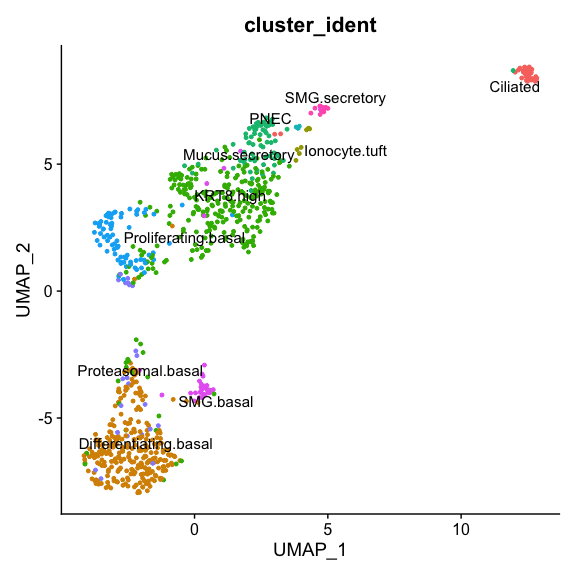

```r
#####Data integration with one single dataset normalized with sctransform method
Int_GSE134174_sct<-SeuObj_integration(Object.list=seu_GSE134174_sct,Frow.which.Norm="sct")
test_meta_sct<-test_meta[row.names(Int_GSE134174_sct@meta.data),]
Int_GSE134174_sct<-Seurat::AddMetaData(object=Int_GSE134174_sct,metadata =as.data.frame(test_meta_sct))
Seurat::DimPlot(Int_GSE134174_sct,group.by="cluster_ident",label=TRUE,repel = TRUE)+ NoLegend()
```

Integrative analysis of datasets from multiple GSE IDs could be powerful to gain additional information. As previous query result, GSE104154 dataset studies the mouse pulmonary fibrotic mesenchymal cells and the authors identify a new subtype of cells (Pdgfrb_hi) in fibrotic stage(Xie,T. (2018)). Another dataset, GSE161648, studies the impact of homeostatic fibrosis when the fas signaling was lost in fibroblasts(Redente, EF. (2020)). Integrative analysis of these two scRNAseq datasets can help us understand how the new subtype of cells found from GSE104154 will be affected by fas signaling.

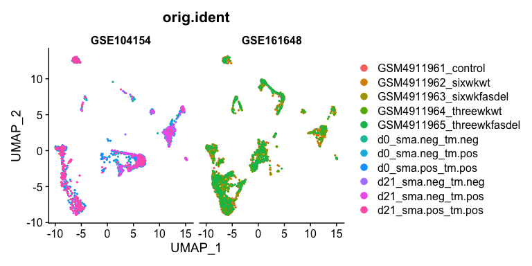

```r
# ##The codes were used to generate the example data list of GSE104154 (only a small subset of the data were used)
#   myGeoList<-c("GSE104154", "GSE161648")
#   myAllF<-Get_Geo_Data(DownGSEID=myGeoList,DecompressFile=TRUE,DecompressType="All")
#   dat_104_raw<-read.csv("GSE104154/GSE104154_d0_d21_sma_tm_Expr_raw.csv")
#   meta_104_2<-as.data.frame(readxl::read_xlsx("GSE104154/GSE104154_cell_type_annotation_d0_d21.xlsx",col_names=T,sheet=2))
#   meta_104_3<-as.data.frame(readxl::read_xlsx("GSE104154/GSE104154_cell_type_annotation_d0_d21.xlsx",col_names=T,sheet=3))
#   meta_104_2_3<-rbind(meta_104_2,meta_104_3)
#   meta_104_2_3$ID<-sapply(strsplit(meta_104_2_3$Barcode,split="\\."),function(x) x[2])
#   sleSize=300
#   sampleInd<-unlist(lapply(unique(meta_104_2_3$ID),function(x) {temp<-meta_104_2_3[meta_104_2_3$ID %in% x,]
#     set.seed(1234);sleSize<-min(nrow(temp),sleSize);SelectCellInd<-sample(1:nrow(temp),size=sleSize,replace=F)
#     returnBarcode<-temp$Barcode[SelectCellInd]}))
#   meta_23<-meta_104_2_3[meta_104_2_3$Barcode %in% sampleInd,]
#   dat_104Raw_withAno<-dat_104_raw[,paste(meta_23$Barcode)]
#   rowSum_dat104Raw<-rowSums(dat_104Raw_withAno)
#   dat_104Raw_f<-dat_104Raw_withAno[rowSum_dat104Raw>0,]
#   removeDupGene<-(!duplicated(dat_104_raw[rowSum_dat104Raw>0,2]))
#   dat_104Raw_f2<-dat_104Raw_f[removeDupGene,]
#   row.names(dat_104Raw_f2)<-dat_104_raw[rowSum_dat104Raw>0,2][removeDupGene]
#   t_datRaw<-data.frame(barcode=sapply(strsplit(colnames(dat_104Raw_f2),split="\\."),function(x) x[2]),t(dat_104Raw_f2))
#   t_datRaw$barcode<-dplyr::recode(t_datRaw$barcode,"1"="d0_sma.pos_tm.pos","2"="d0_sma.neg_tm.pos",
#   "3"="d0_sma.neg_tm.neg", "4"="d21_sma.pos_tm.pos","5"="d21_sma.neg_tm.pos","6"="d21_sma.neg_tm.neg")
#   RawDataList_GSE104154<-Splitdata_MakeDataList(InputData=t(t_datRaw[,2:ncol(t_datRaw)]),Group=t_datRaw$barcode)
#   meta_GSE104154<-meta_23
#
# ##The codes were used to generate the example data list of GSE161648
#   GEO_ID<-"GSE161648"
#   list_barcodefile<-list.files(GEO_ID,pattern="*_barcodes.tsv.gz")
#   (sampleName<-gsub("_barcodes.tsv.gz","",list_barcodefile))
#   sapply(sampleName,function(x){
#     NewSampleFolder<-sprintf("%s/%s",GEO_ID,x)
#     if (!file.exists(NewSampleFolder)){dir.create(NewSampleFolder)}
#     file.copy(sprintf("%s/%s_barcodes.tsv.gz",GEO_ID,x), sprintf("%s/barcodes.tsv.gz",NewSampleFolder))
#     file.copy(sprintf("%s/%s_matrix.mtx.gz",GEO_ID,x), sprintf("%s/matrix.mtx.gz",NewSampleFolder))
#     file.copy(sprintf("%s/%s_features.tsv.gz",GEO_ID,x), sprintf("%s/features.tsv.gz",NewSampleFolder))
#   })
#   GSE161648_10xRawData<-sapply(sampleName,function(x){rawdata<- Seurat::Read10X(data.dir =sprintf("%s/%s",GEO_ID,x))})
#   sleSize1=500
#   RawDataList_GSE161648<-lapply(GSE161648_10xRawData,function(x){sleSize1<-min(ncol(as.matrix(x)),sleSize1)
#     set.seed(1234);SelectCellInd<-sample(1:ncol(as.matrix(x)),size=sleSize1,replace=F)
#     returnCell<-(as.matrix(x))[,SelectCellInd]})

  ##load the example data
  data(Dat_GSE54_GSE48)
  RawDataList_GSE104154<-Dat_GSE54_GSE48$dat_GSE104154$RawDataList
  meta_GSE104154<-Dat_GSE54_GSE48$dat_GSE104154$MetaData
  row.names(meta_GSE104154)<-meta_GSE104154$Barcode
  RawDataList_GSE161648<-Dat_GSE54_GSE48$dat_GSE161648$RawDataList
  ###make Seurat object fro the raw data
  seu_GSE104154_raw<-MakeSeuObj_FromRawRNAData(RawList=RawDataList_GSE104154,
                                               GSE.ID="GSE104154",
                                               MtPattern='^mt-',
                                               MinFeature=1,
                                               MaxFeature=750000,
                                               MinCount=1,
                                               MaxCount=4000000,
                                               MaxMT=100)
  seu_GSE161648_raw<-MakeSeuObj_FromRawRNAData(RawList=RawDataList_GSE161648,GSE.ID="GSE161648",MtPattern='^mt-')
  ###Data integration
  Int_GSE54_GSE48<-SeuObj_integration(Object.list=seu_GSE104154_raw,Object.list2=seu_GSE161648_raw)

  ###Evaluate the potential batch effect
  Seurat::DimPlot(Int_GSE54_GSE48,group.by="orig.ident",split.by="GSE",repel = TRUE)
```